# Untitled

# RStudio Exercise 5

## Data wrangling

See file `create_human.R` in [my GitHub repository](https://github.com/opalmen/IODS-project/tree/master/data)

## Analysis

First, load the data

```r
human = read.table("data/human.csv", header=TRUE, sep=" ")
```

Access library `GGally`, `corrplot` to be used in the analysis

```r
library(GGally)
```

```r
library(corrplot)
library(dplyr)
```

Next we summarize the data

```r
summary(human)
```

```
##    Edu2.Ratio       LFP.Ratio         Life.Exp        Edu.Exp
##  Min.   :0.1717   Min.   :0.1857   Min.   :49.00   Min.   : 5.40
##  1st Qu.:0.7264   1st Qu.:0.5984   1st Qu.:66.30   1st Qu.:11.25
##  Median :0.9375   Median :0.7535   Median :74.20   Median :13.50
##  Mean   :0.8529   Mean   :0.7074   Mean   :71.65   Mean   :13.18
##  3rd Qu.:0.9968   3rd Qu.:0.8535   3rd Qu.:77.25   3rd Qu.:15.20
##  Max.   :1.4967   Max.   :1.0380   Max.   :83.50   Max.   :20.20
##       GNI            Mat.Mor         Ado.Birth         Parli.F
##  Min.   :   581   Min.   :   1.0   Min.   :  0.60   Min.   : 0.00
##  1st Qu.:  4198   1st Qu.:  11.5   1st Qu.: 12.65   1st Qu.:12.40
##  Median : 12040   Median :  49.0   Median : 33.60   Median :19.30
##  Mean   : 17628   Mean   : 149.1   Mean   : 47.16   Mean   :20.91
##  3rd Qu.: 24512   3rd Qu.: 190.0   3rd Qu.: 71.95   3rd Qu.:27.95
##  Max.   :123124   Max.   :1100.0   Max.   :204.80   Max.   :57.50
```

We can see that lowest life expectancy (`Life.Exp`) is 49 years and the highest is 83.5. The data also shows that the share of female participants in parliament (`Parli.F`) varies between countries, ranging from 0 to 57.5 %. On average, females obtain less education than males (`Edu2.Ratio`) and particpate less in the labor force (`LFP.Ratio`)

### Data visualization

Next, we visualize the data

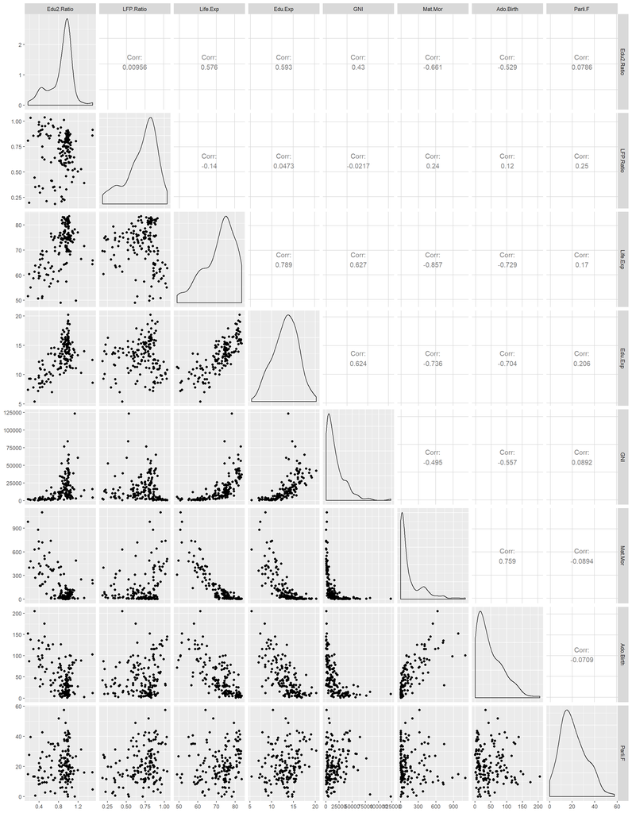

```r
# visualize the 'human' variables
ggpairs(human)
```

Looking in more detail at the correlations in the figure below, we can see some expected relationships.

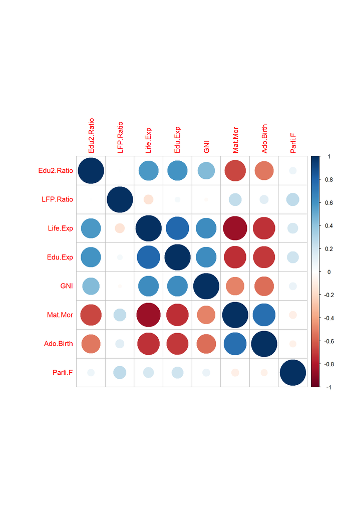

```r
# compute the correlation matrix and visualize it with corrplot
cor(human) %>% corrplot
```

Maternal mortality (`Mat.Mor`) and adolescent fertility rate (`Ado.Birth`) are negatively correlated with relative education of female to male (`Edu2.Ratio`) and gross national income (`GNI`). `GNI` is positively correlated with female education `Edu2.Ratio` and life expectancy (`Life.Exp`) and expected education (`Edu.Exp`).

### Principal components analysis (non-standardized data)

Next we perform principal components analysis (PCA) on the data.

```r
# perform principal component analysis
pca_human <- prcomp(human)
summary(pca_human)
```

```
## Importance of components:
##                              PC1      PC2   PC3   PC4   PC5   PC6    PC7
## Standard deviation     1.854e+04 185.5219 25.19 11.45 3.766 1.566 0.1912
## Proportion of Variance 9.999e-01   0.0001  0.00  0.00 0.000 0.000 0.0000
## Cumulative Proportion  9.999e-01   1.0000  1.00  1.00 1.000 1.000 1.0000
##                           PC8
## Standard deviation     0.1591
## Proportion of Variance 0.0000
## Cumulative Proportion  1.0000
```

The above table shows that the first principal component (PC1) explains 99% of the variation in the data, suggesting that the data can be summarized in single dimension.

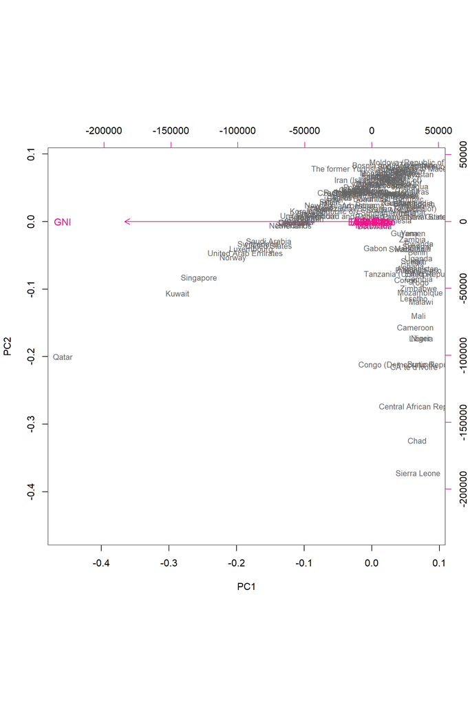

```r
biplot(pca_human, choices = 1:2, cex = c(0.8, 1), col = c("grey40", "deeppink2"))
```

The biplot shows that the first principal component explain much of the cross-country variation, which is largely driven by gross national income (`GNI`).

### Principle components analysis (standardized data)

```r
# perform principal component analysis (with the SVD method)
human_std <- scale(human)
```

```r
# perform principal component analysis (with the SVD method)
pca_human_std <- prcomp(human_std)
```

```r
summary(pca_human_std)
```

```
## Importance of components:
##                           PC1    PC2     PC3     PC4     PC5     PC6
## Standard deviation     2.0708 1.1397 0.87505 0.77886 0.66196 0.53631
## Proportion of Variance 0.5361 0.1624 0.09571 0.07583 0.05477 0.03595
## Cumulative Proportion  0.5361 0.6984 0.79413 0.86996 0.92473 0.96069
##                            PC7     PC8
## Standard deviation     0.45900 0.32224
## Proportion of Variance 0.02634 0.01298
## Cumulative Proportion  0.98702 1.00000
```

Using the standardized data, we can see that now the first five principal components explain 92% of the variation in the data, whereas the first principal component explained most of the variation in the non-standardized data.

This can be largely explained by the the large values of the GNI that are driving the results, whereas this is avoided by using the standardized data.

This can be seen clearly in the figure below:

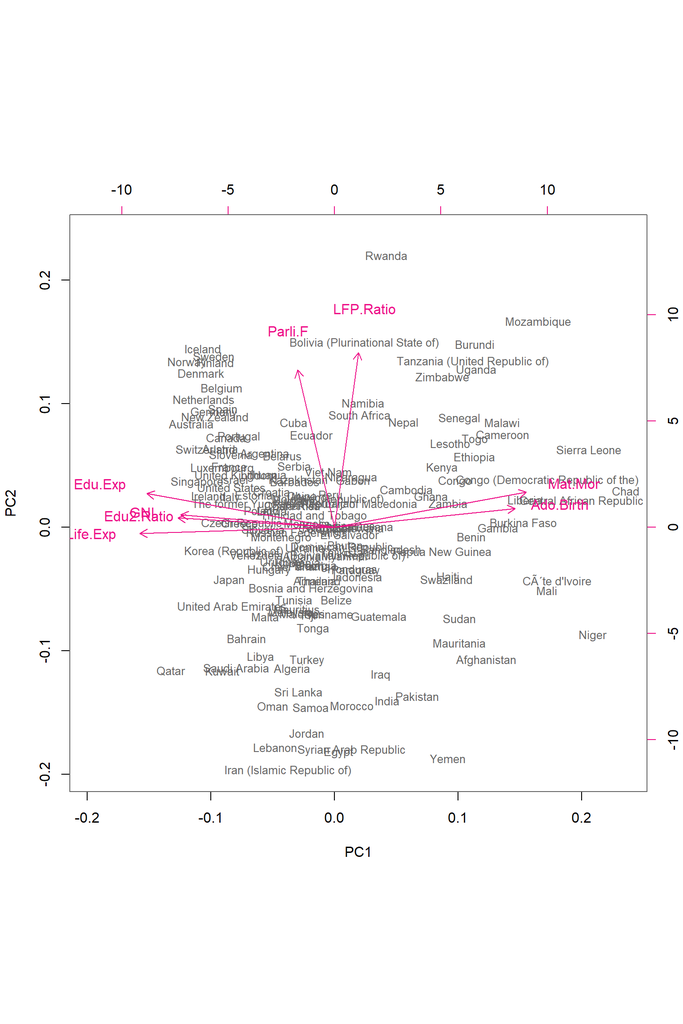

```r
# draw a biplot of the principal component representation and the original variables
biplot(pca_human_std, choices = 1:2, cex = c(0.8, 1), col = c("grey40", "deeppink2"))
```

We can see that gross national income (`GNI`), female participation in secondary education (`Edu2.Ratio`), expected years of education (`Edu.Exp`) and life expectancy (`Life.Exp`) have large negative weights on the first principal component (PC1), whereas maternal mortality (`Mat.Mor`) and adolescent birth rate (`Ado.Birth`) have positive weights on PC1.

Moreover, female participation in the labor force relative to men (`LFP.Ratio`) and participation in the parliamenet (`Parli.F`) have positive weights on PC2.

### Interpretation of principal components

The above suggests that PC1 seems to explain economic differences between countries, given that variables associated with economic development, such as gross national income and health have the largest weights on PC1.

PC2 may be interpreted as a measure of gender inequality, because it is largely driven by female participation in the parliament and relative labor force participation.

### Tea dataset from FactoMineR

Install package `FactoMineR`, load dataset `tea`. The data is on a questionnaire on tea consumption, product perception and personal details.

First, explore that data:

```r
install.packages('FactoMineR', repos = "http://cloud.r-project.org")
library(FactoMineR)
data(tea)
```

```r
summary(tea)
```

```
##          breakfast           tea.time          evening          lunch
##  breakfast    :144   Not.tea time:131   evening    :103   lunch    : 44
##  Not.breakfast:156   tea time    :169   Not.evening:197   Not.lunch:256
##
##
##
##
##
##         dinner           always          home           work
##  dinner    : 21   always    :103   home    :291   Not.work:213
##  Not.dinner:279   Not.always:197   Not.home:  9   work    : 87
##
##
##
##
##
##         tearoom           friends          resto          pub
##  Not.tearoom:242   friends    :196   Not.resto:221   Not.pub:237
##  tearoom    : 58   Not.friends:104   resto    : 79   pub    : 63
##
##
##
##
##
##         Tea         How           sugar                     how
##  black    : 74   alone:195   No.sugar:155   tea bag           :170
##  Earl Grey:193   lemon: 33   sugar   :145   tea bag+unpackaged: 94
##  green    : 33   milk : 63                  unpackaged        : 36
##                  other:  9
##
##
##
##                   where                 price          age        sex
##  chain store         :192   p_branded      : 95   Min.   :15.00   F:178
##  chain store+tea shop: 78   p_cheap        :  7   1st Qu.:23.00   M:122
##  tea shop            : 30   p_private label: 21   Median :32.00
##                             p_unknown      : 12   Mean   :37.05
##                             p_upscale      : 53   3rd Qu.:48.00
##                             p_variable     :112   Max.   :90.00
##
```

[output cut: 25 more lines]

```
##  feminine    :129   Not.sophisticated: 85   No.slimming:255
##  Not.feminine:171   sophisticated    :215   slimming   : 45
##
##
##
##
##
##         exciting          relaxing              effect.on.health
##  exciting   :116   No.relaxing:113   effect on health   : 66
##  No.exciting:184   relaxing   :187   No.effect on health:234
##
##
##
##
##
```

```r
str(tea)
```

```
## 'data.frame':    300 obs. of  36 variables:
##  $ breakfast       : Factor w/ 2 levels "breakfast","Not.breakfast": 1 1 2 2 1 2 1 2 1 1 ...
##  $ tea.time        : Factor w/ 2 levels "Not.tea time",..: 1 1 2 1 1 1 2 2 2 1 ...
##  $ evening         : Factor w/ 2 levels "evening","Not.evening": 2 2 1 2 1 2 2 1 2 1 ...
##  $ lunch           : Factor w/ 2 levels "lunch","Not.lunch": 2 2 2 2 2 2 2 2 2 2 ...
##  $ dinner          : Factor w/ 2 levels "dinner","Not.dinner": 2 2 1 1 2 1 2 2 2 2 ...
##  $ always          : Factor w/ 2 levels "always","Not.always": 2 2 2 2 1 2 2 2 2 2 ...
##  $ home            : Factor w/ 2 levels "home","Not.home": 1 1 1 1 1 1 1 1 1 1 ...
##  $ work            : Factor w/ 2 levels "Not.work","work": 1 1 2 1 1 1 1 1 1 1 ...
##  $ tearoom         : Factor w/ 2 levels "Not.tearoom",..: 1 1 1 1 1 1 1 1 1 2 ...
##  $ friends         : Factor w/ 2 levels "friends","Not.friends": 2 2 1 2 2 2 1 2 2 2 ...
##  $ resto           : Factor w/ 2 levels "Not.resto","resto": 1 1 2 1 1 1 1 1 1 1 ...
##  $ pub             : Factor w/ 2 levels "Not.pub","pub": 1 1 1 1 1 1 1 1 1 1 ...
##  $ Tea             : Factor w/ 3 levels "black","Earl Grey",..: 1 1 2 2 2 2 2 1 2 1 ...
##  $ How             : Factor w/ 4 levels "alone","lemon",..: 1 3 1 1 1 1 1 3 3 1 ...
```

[output cut: 22 more lines]

The data includes 300 observations of 36 variables.

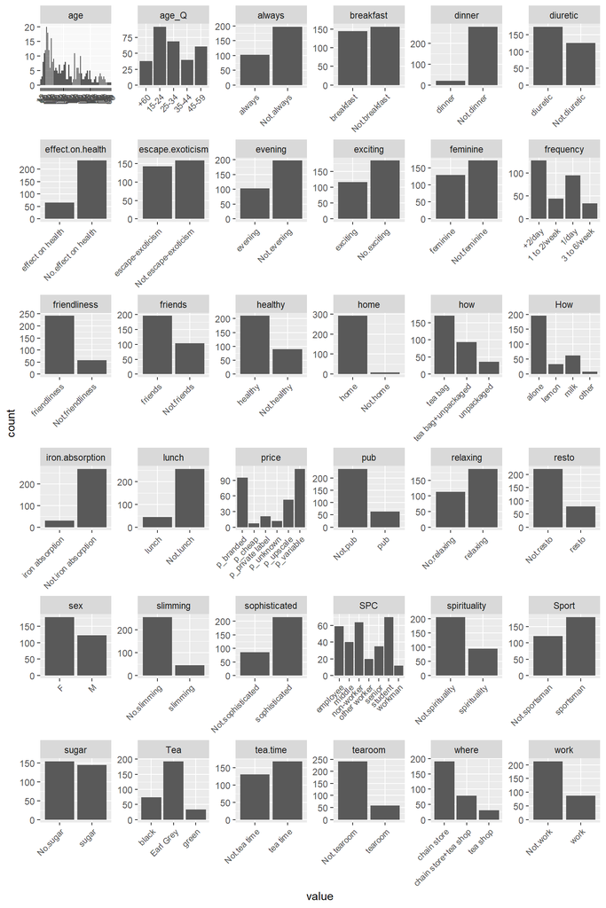

```r
# visualize the dataset
library(tidyr)
gather(tea) %>% ggplot(aes(value)) + facet_wrap("key", scales = "free") + geom_bar() + theme(axis.text.x = element_text(angle = 45, hjust = 1, size = 8))
```

```r
# column names to keep in the dataset
keep_columns <- c("Tea", "How", "how", "where")

# select the 'keep_columns' to create a new dataset
tea_vars <- select(tea, one_of(keep_columns))
head(tea_vars)
```

```
##         Tea   How     how       where
## 1     black alone tea bag chain store
## 2     black  milk tea bag chain store
## 3 Earl Grey alone tea bag chain store
## 4 Earl Grey alone tea bag chain store
## 5 Earl Grey alone tea bag chain store
## 6 Earl Grey alone tea bag chain store
```

```r
# multiple correspondence analysis
mca <- MCA(tea_vars, graph = FALSE)
# summary of the model
summary(mca)
```

```
##
## Call:
## MCA(X = tea_vars, graph = FALSE)
##
##
## Eigenvalues
##                        Dim.1   Dim.2   Dim.3   Dim.4   Dim.5   Dim.6
## Variance               0.413   0.386   0.293   0.262   0.248   0.225
## % of var.             18.368  17.142  13.020  11.650  11.026   9.994
## Cumulative % of var.  18.368  35.510  48.531  60.181  71.207  81.201
##                        Dim.7   Dim.8   Dim.9
## Variance               0.197   0.131   0.095
## % of var.              8.735   5.842   4.222
## Cumulative % of var.  89.936  95.778 100.000
##
## Individuals (the 10 first)
##                       Dim.1    ctr   cos2    Dim.2    ctr   cos2    Dim.3
## 1                  | -0.313  0.079  0.080 | -0.333  0.096  0.090 |  0.653
## 2                  | -0.427  0.147  0.090 | -0.143  0.018  0.010 |  0.980
## 3                  | -0.531  0.228  0.466 | -0.365  0.115  0.221 | -0.188
## 4                  | -0.531  0.228  0.466 | -0.365  0.115  0.221 | -0.188
## 5                  | -0.531  0.228  0.466 | -0.365  0.115  0.221 | -0.188
## 6                  | -0.531  0.228  0.466 | -0.365  0.115  0.221 | -0.188
## 7                  | -0.531  0.228  0.466 | -0.365  0.115  0.221 | -0.188
## 8                  | -0.427  0.147  0.090 | -0.143  0.018  0.010 |  0.980
## 9                  |  0.058  0.003  0.001 |  1.078  1.005  0.497 | -0.234
## 10                 |  0.391  0.123  0.071 |  0.921  0.734  0.394 |  0.280
##                       ctr   cos2
## 1                   0.485  0.347 |
## 2                   1.094  0.472 |
## 3                   0.040  0.059 |
## 4                   0.040  0.059 |
## 5                   0.040  0.059 |
## 6                   0.040  0.059 |
## 7                   0.040  0.059 |
## 8                   1.094  0.472 |
## 9                   0.062  0.023 |
## 10                  0.089  0.036 |
##
## Categories (the 10 first)
```

[output cut: 14 more lines]

```
## green                0.113  -5.808 |  -0.353   1.167   0.015  -2.143 |
## alone                0.128  -6.178 |  -0.171   1.620   0.054  -4.027 |
## lemon                0.038   3.387 |  -0.893   7.483   0.099  -5.428 |
## milk                 0.012   1.863 |   0.538   5.183   0.077   4.795 |
## other                0.146   6.613 |   3.212  26.413   0.319   9.768 |
## tea bag              0.173  -7.186 |   0.131   0.830   0.022   2.591 |
## tea bag+unpackaged   0.465  11.797 |  -0.378   3.830   0.065  -4.421 |
## unpackaged           0.116  -5.880 |   0.369   1.398   0.019   2.359 |
##
## Categorical variables (eta2)
##                      Dim.1 Dim.2 Dim.3
## Tea                | 0.083 0.114 0.607 |
## How                | 0.100 0.230 0.477 |
## how                | 0.725 0.496 0.071 |
## where              | 0.744 0.703 0.017 |
```

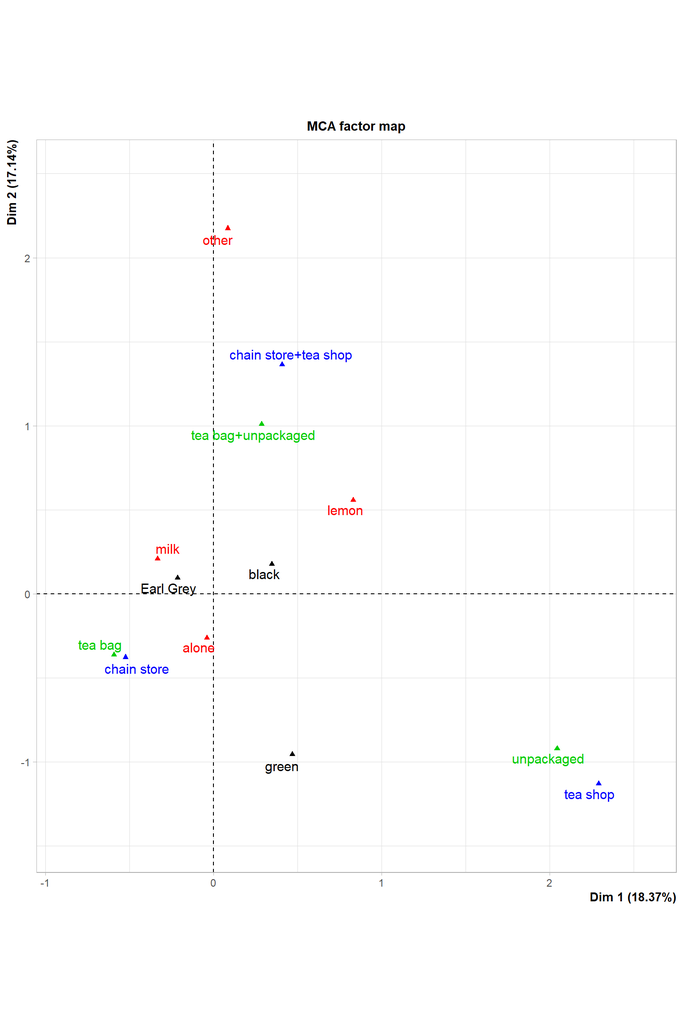

```r
# visualize MCA
plot(mca, invisible=c("ind"), habillage = "quali")
```

Dimension 1 and Dimension 2 explain 18,4 % and 17,1% of the variation, respectively. The summary of the model shows that first four dimensions explain roughly 60 percent of the variation in the model.